# Assignment2_rspake1

## Question 1

While studying for this module, I had created the cats and dogs test/validation/train following the steps in the book, so I am simply reusing the same directories here.

```r
base_dir <- "~/Cats_and_dogs_small/archive/cats_and_dogs_small"

train_dir <- "~/Cats_and_dogs_small/archive/cats_and_dogs_small/train"
validation_dir <- "~/Cats_and_dogs_small/archive/cats_and_dogs_small/validation"
test_dir <- "~/Cats_and_dogs_small/archive/cats_and_dogs_small/test"

train_cats_dir <- "~/Cats_and_dogs_small/archive/cats_and_dogs_small/train/cats"

train_dogs_dir <- "~/Cats_and_dogs_small/archive/cats_and_dogs_small/train/dogs"

Validation_dogs_dir <- "~/Cats_and_dogs_small/archive/cats_and_dogs_small/validation/dogs"

Validation_cats_dir <- "~/Cats_and_dogs_small/archive/cats_and_dogs_small/validation/cats"

test_cats_dir <- "~/Cats_and_dogs_small/archive/cats_and_dogs_small/test/cats"

test_dogs_dir <- "~/Cats_and_dogs_small/archive/cats_and_dogs_small/test/cats"
```

## Building the base model

Following the steps in the model/book, after establishing the directories, we are now building the base model with layer_conv_2d with relu activation, max pooling, finally flattening and a final dense layer with sigmoid activation.

Lastly, we will take a look at the model to make sure we have built it properly.

```r
library(keras)
model1 <- keras_model_sequential() %>%
  layer_conv_2d(filters = 32, kernel_size = c(3, 3), activation = "relu",
                input_shape = c(150, 150, 3)) %>%
  layer_max_pooling_2d(pool_size = c(2, 2)) %>%
  layer_conv_2d(filters = 64, kernel_size = c(3, 3), activation = "relu") %>%
  layer_max_pooling_2d(pool_size = c(2, 2)) %>%
  layer_conv_2d(filters = 128, kernel_size = c(3, 3), activation = "relu") %>%
  layer_max_pooling_2d(pool_size = c(2, 2)) %>%
  layer_conv_2d(filters = 128, kernel_size = c(3, 3), activation = "relu") %>%
  layer_max_pooling_2d(pool_size = c(2, 2)) %>%
  layer_flatten() %>%
  layer_dense(units = 512, activation = "relu") %>%
  layer_dense(units = 1, activation = "sigmoid")
```

```
## Loaded Tensorflow version 2.8.0
```

```r
summary(model1)
```

```
## Model: "sequential"
## ________________________________________________________________________________
##  Layer (type)                       Output Shape                    Param #
## ================================================================================
##  conv2d_3 (Conv2D)                  (None, 148, 148, 32)            896
##
##  max_pooling2d_3 (MaxPooling2D)     (None, 74, 74, 32)              0
##
##  conv2d_2 (Conv2D)                  (None, 72, 72, 64)              18496
##
##  max_pooling2d_2 (MaxPooling2D)     (None, 36, 36, 64)              0
##
##  conv2d_1 (Conv2D)                  (None, 34, 34, 128)             73856
##
##  max_pooling2d_1 (MaxPooling2D)     (None, 17, 17, 128)             0
##
##  conv2d (Conv2D)                    (None, 15, 15, 128)             147584
##
##  max_pooling2d (MaxPooling2D)       (None, 7, 7, 128)               0
##
##  flatten (Flatten)                  (None, 6272)                    0
##
##  dense_1 (Dense)                    (None, 512)                     3211776
##
##  dense (Dense)                      (None, 1)                       513
##
## ================================================================================
## Total params: 3,453,121
## Trainable params: 3,453,121
## Non-trainable params: 0
## ________________________________________________________________________________
```

Since our last layer in a sigmoid, we will use binary crossentropy as the loss function, as stipulated in the chart in chapter 4 of the book.

```r
model1 %>% compile(
  loss = "binary_crossentropy",
  optimizer = optimizer_rmsprop(learning_rate = 1e-4),
  metrics = c("acc")
)
```

## Preprocessing of our data

```r
train_datagen <- image_data_generator(rescale = 1/255)
validation_datagen <- image_data_generator(rescale = 1/255)

train_generator <- flow_images_from_directory(
  train_dir,
  train_datagen,
  target_size = c(150,150),
  batch_size = 20,
  class_mode = "binary"
)

validation_generator <- flow_images_from_directory(
  validation_dir,
  validation_datagen,
  target_size = c(150,150),
  batch_size = 20,
  class_mode = "binary"
)

batch <- generator_next(train_generator)
str(batch)
```

```
## List of 2
##  $ : num [1:20, 1:150, 1:150, 1:3] 0.6039 0.9765 0.4314 0.2471 0.0627 ...
##  $ : num [1:20(1d)] 0 0 1 0 1 1 1 0 1 1 ...
```

Now it is time to fit the model the the data.

```r
history1 <- model1 %>% fit_generator(
  train_generator,
  steps_per_epoch = 100,
  epochs = 30,
  validation_data = validation_generator,
  validation_steps = 50
)
```

As we see in the plot below of History1, the model has an “elbow” point around 18 epochs and is suffering from some heavy overfitting with a val accuracy of 7.5 as a relative high point. loss: 0.2096 - acc: 0.9255 - val_loss: 0.5929 - val_acc: 0.7500

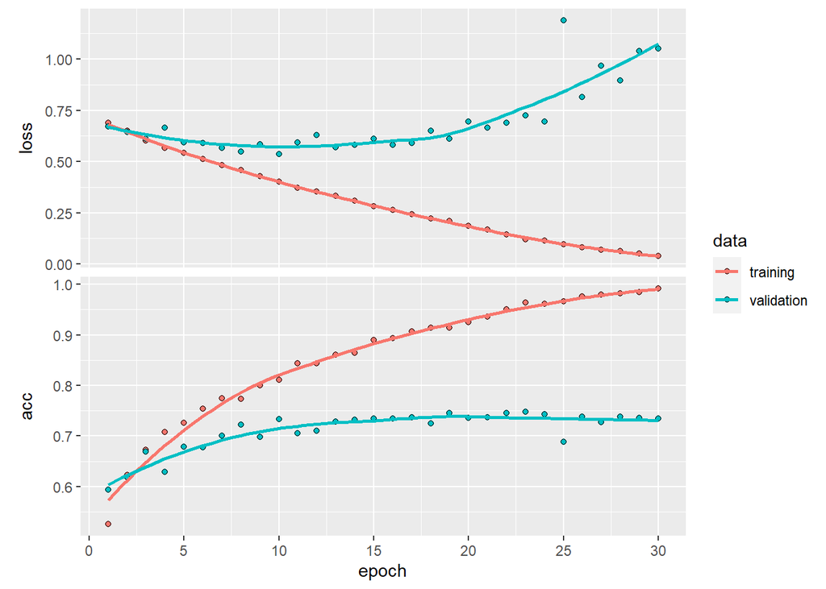

```r
plot(history1)
```

```r
model1 %>% save_model_hdf5("cats_and_dogs_small_1.h5")
```

#Optimizing using dropout and augmentation We will optimize our model by using augmentation and dropout to combat overfitting.

- First we will apply dropout, by adding a dropout layer in the model itself.

```r
model1.2 <- keras_model_sequential() %>%
  layer_conv_2d(filters = 32, kernel_size = c(3, 3), activation = "relu",
                input_shape = c(150, 150, 3)) %>%
  layer_max_pooling_2d(pool_size = c(2, 2)) %>%
  layer_conv_2d(filters = 64, kernel_size = c(3, 3), activation = "relu") %>%
  layer_max_pooling_2d(pool_size = c(2, 2)) %>%
  layer_conv_2d(filters = 128, kernel_size = c(3, 3), activation = "relu") %>%
  layer_max_pooling_2d(pool_size = c(2, 2)) %>%
  layer_conv_2d(filters = 128, kernel_size = c(3, 3), activation = "relu") %>%
  layer_max_pooling_2d(pool_size = c(2, 2)) %>%
  layer_flatten() %>%
  layer_dropout(rate = 0.5) %>%
  layer_dense(units = 512, activation = "relu") %>%
  layer_dense(units = 1, activation = "sigmoid")

model1.2 %>% compile(
  loss = "binary_crossentropy",
  optimizer = optimizer_rmsprop(learning_rate = 1e-4),
  metrics = c("acc")
)
```

Now we will apply augmentation to the train images.

```r
datagen <- image_data_generator(
  rescale = 1/255,
  rotation_range = 40,
  width_shift_range = 0.2,
  height_shift_range = 0.2,
  shear_range = 0.2,
  zoom_range = 0.2,
  horizontal_flip = TRUE
)

test_datagen <- image_data_generator(rescale = 1/255)

train_generator <- flow_images_from_directory(
  train_dir,
  datagen,
  target_size = c(150, 150),
  batch_size = 20,
  class_mode = "binary"
)

validation_generator <- flow_images_from_directory(
  validation_dir,
  test_datagen,
  target_size = c(150, 150),
  batch_size = 20,
  class_mode = "binary"
)
```

Now lets check the history with these changes and see how this new model holds up.

```r
history1.2 <- model1.2 %>% fit_generator(
  train_generator,
  steps_per_epoch = 100,
  epochs = 100,
  validation_data = validation_generator,
  validation_steps = 50
)
```

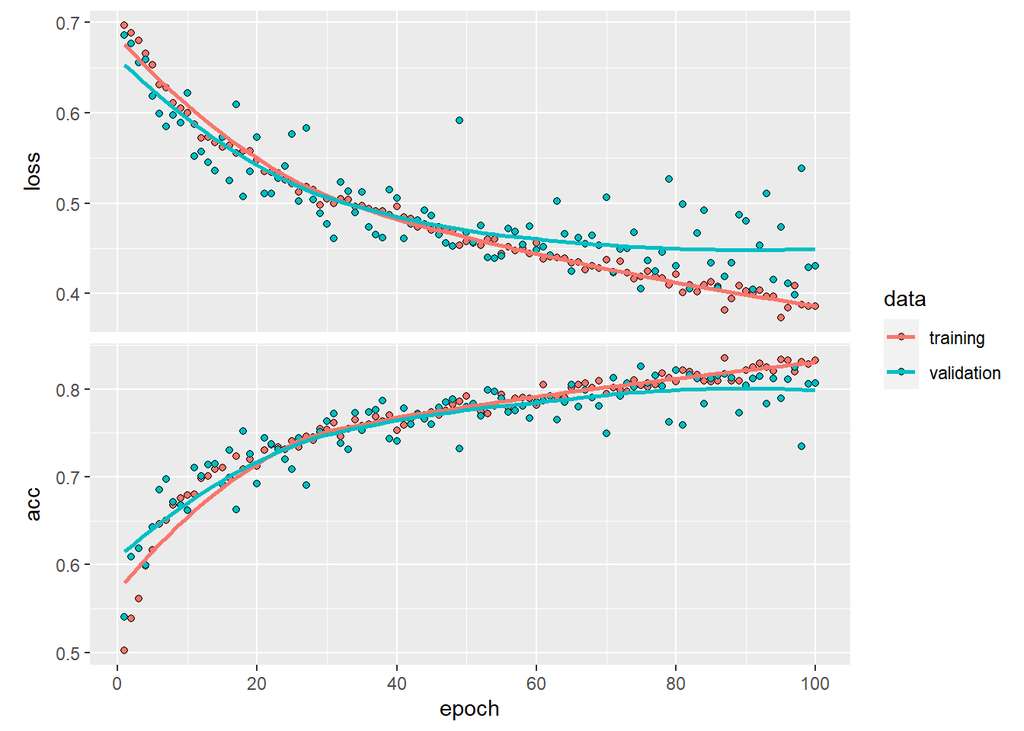

```r
plot(history1.2)
```

Though this output is very hectic, its output is much more accurate than previously.

```r
model1.2 %>% save_model_hdf5("cats_and_dogs_small_1.2.h5")
```

## Question 2

Now we will increase the training data set so that we have more samples to train with.

```r
train_dir2 <- "~/Cats_and_dogs_small/archive/cats_and_dogs_big/train"

train_cats_dir2 <- "~/Cats_and_dogs_small/archive/cats_and_dogs_big/train/cats"

train_dogs_dir2 <- "~/Cats_and_dogs_small/archive/cats_and_dogs_big/train/dogs"
```

with the above code, we have called new train data for both cats and dogs that consists of 1500 units of training data for each. Now we will apply this new train set to our model.

```r
train_generator2 <- flow_images_from_directory(
  train_dir2,
  train_datagen,
  target_size = c(150,150),
  batch_size = 20,
  class_mode = "binary"
)

batch <- generator_next(train_generator2)
str(batch)
```

```
## List of 2
##  $ : num [1:20, 1:150, 1:150, 1:3] 0.0784 0.3961 0.7961 0.7529 0.502 ...
##  $ : num [1:20(1d)] 0 0 1 1 0 0 0 1 0 1 ...
```

Now we will apply the new data to the base model.

```r
history2 <- model1 %>% fit_generator(
  train_generator2,
  steps_per_epoch = 100,
  epochs = 30,
  validation_data = validation_generator,
  validation_steps = 50
)
```

Looking at the plot bellow we can see how increasing the sample size effects the output.

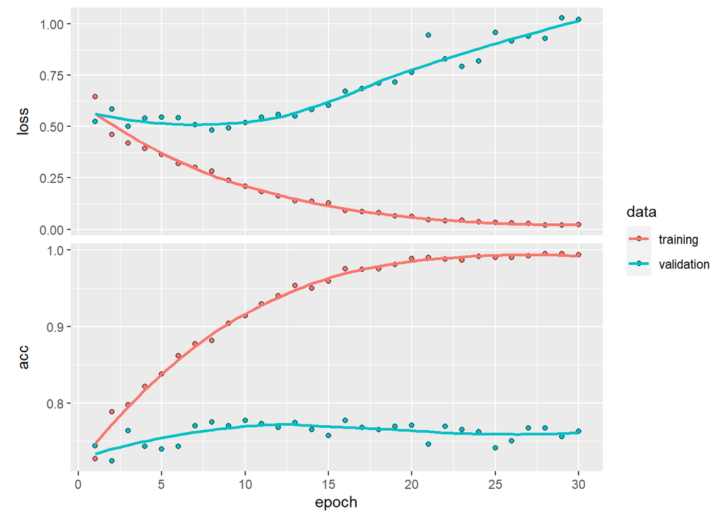

```r
plot(history2)
```

#Optimizing the new model using dropout and augmentation We will optimize our model by using augmentation and dropout to combat overfitting.

- First we will apply dropout, by adding a dropout layer in the model itself.

```r
model2.2 <- keras_model_sequential() %>%
  layer_conv_2d(filters = 32, kernel_size = c(3, 3), activation = "relu",
                input_shape = c(150, 150, 3)) %>%
  layer_max_pooling_2d(pool_size = c(2, 2)) %>%
  layer_conv_2d(filters = 64, kernel_size = c(3, 3), activation = "relu") %>%
  layer_max_pooling_2d(pool_size = c(2, 2)) %>%
  layer_conv_2d(filters = 128, kernel_size = c(3, 3), activation = "relu") %>%
  layer_max_pooling_2d(pool_size = c(2, 2)) %>%
  layer_conv_2d(filters = 128, kernel_size = c(3, 3), activation = "relu") %>%
  layer_max_pooling_2d(pool_size = c(2, 2)) %>%
  layer_flatten() %>%
  layer_dropout(rate = 0.5) %>%
  layer_dense(units = 512, activation = "relu") %>%
  layer_dense(units = 1, activation = "sigmoid")

model2.2 %>% compile(
  loss = "binary_crossentropy",
  optimizer = optimizer_rmsprop(learning_rate = 1e-4),
  metrics = c("acc")
)
```

Now we will apply augmentation to the train images of the new trainign sample.

```r
datagen <- image_data_generator(
  rescale = 1/255,
  rotation_range = 40,
  width_shift_range = 0.2,
  height_shift_range = 0.2,
  shear_range = 0.2,
  zoom_range = 0.2,
  horizontal_flip = TRUE
)

test_datagen <- image_data_generator(rescale = 1/255)

train_generator2.2 <- flow_images_from_directory(
  train_dir2,
  datagen,
  target_size = c(150, 150),
  batch_size = 20,
  class_mode = "binary"
)

validation_generator <- flow_images_from_directory(
  validation_dir,
  test_datagen,
  target_size = c(150, 150),
  batch_size = 20,
  class_mode = "binary"
)
```

Now that we have augmented the images, we will apply them to the model.

```r
history2.2 <- model2.2 %>% fit_generator(
  train_generator2.2,
  steps_per_epoch = 100,
  epochs = 100,
  validation_data = validation_generator,
  validation_steps = 50
)
```

In this new Augmented model, the best performance happens at 95 with ~ val_loss: 0.3936 and val_acc: 0.8240

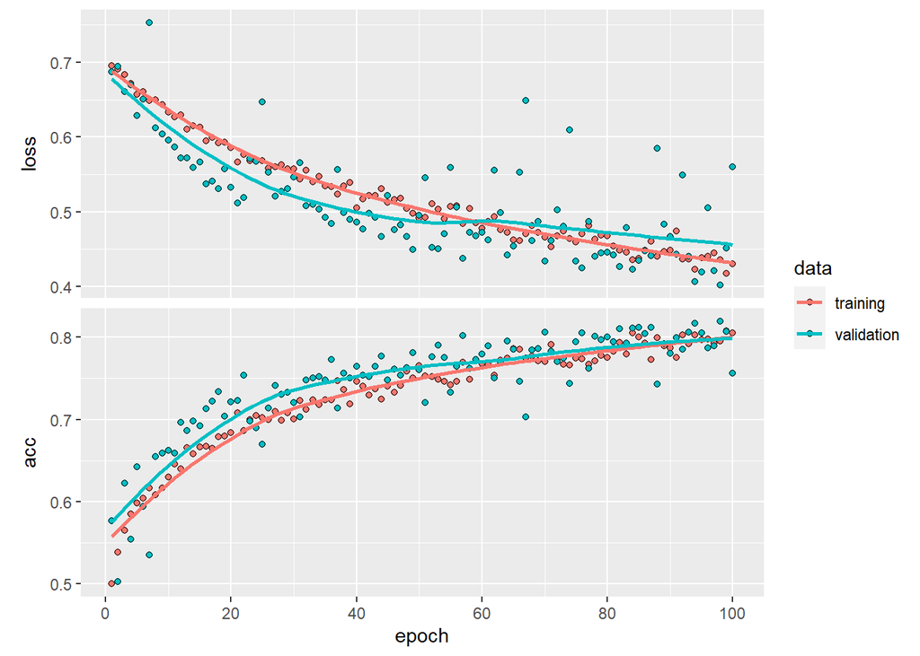

```r
plot(history2.2)
```

## Question 3

This time we will use the entirety of the data that is not in test or validation to train.

```r
train_dir3 <- "~/Cats_and_dogs_small/archive/cats_and_dogs_all/train"

train_cats_dir3 <- "~/Cats_and_dogs_small/archive/cats_and_dogs_all/train/cats"

train_dogs_dir3 <- "~/Cats_and_dogs_small/archive/cats_and_dogs_all/train/dogs"
```

```r
train_generator3 <- flow_images_from_directory(
  train_dir3,
  train_datagen,
  target_size = c(150,150),
  batch_size = 20,
  class_mode = "binary"
)

batch <- generator_next(train_generator3)
str(batch)
```

```
## List of 2
##  $ : num [1:20, 1:150, 1:150, 1:3] 0.502 0.933 0.298 0.769 0.792 ...
##  $ : num [1:20(1d)] 0 0 1 1 1 1 0 0 1 0 ...
```

Now we will apply the new data to the base model.

```r
history3 <- model1 %>% fit_generator(
  train_generator3,
  steps_per_epoch = 100,
  epochs = 30,
  validation_data = validation_generator,
  validation_steps = 50
)
```

Looking at the plot bellow we can see how increasing the sample size effects the output.

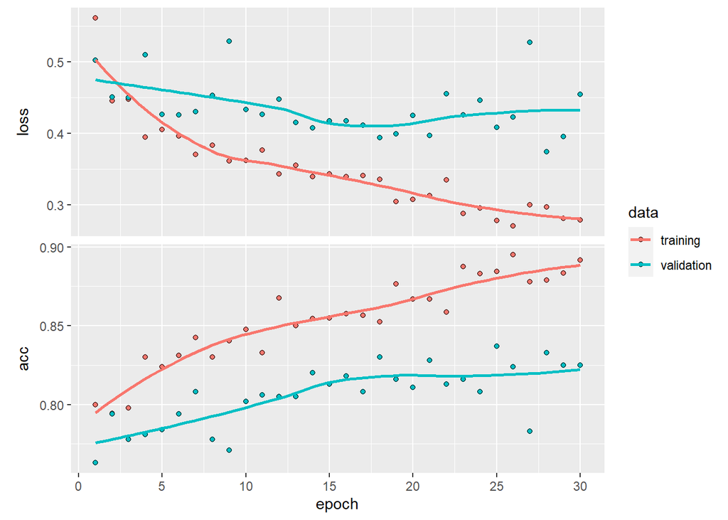

```r
plot(history3)
```

#Optimizing the new model using dropout and augmentation We will optimize our model by using augmentation and dropout to combat overfitting.

- First we will apply dropout, by adding a dropout layer in the model itself.

```r
model3.2 <- keras_model_sequential() %>%
  layer_conv_2d(filters = 32, kernel_size = c(3, 3), activation = "relu",
                input_shape = c(150, 150, 3)) %>%
  layer_max_pooling_2d(pool_size = c(2, 2)) %>%
  layer_conv_2d(filters = 64, kernel_size = c(3, 3), activation = "relu") %>%
  layer_max_pooling_2d(pool_size = c(2, 2)) %>%
  layer_conv_2d(filters = 128, kernel_size = c(3, 3), activation = "relu") %>%
  layer_max_pooling_2d(pool_size = c(2, 2)) %>%
  layer_conv_2d(filters = 128, kernel_size = c(3, 3), activation = "relu") %>%
  layer_max_pooling_2d(pool_size = c(2, 2)) %>%
  layer_flatten() %>%
  layer_dropout(rate = 0.5) %>%
  layer_dense(units = 512, activation = "relu") %>%
  layer_dense(units = 1, activation = "sigmoid")

model3.2 %>% compile(
  loss = "binary_crossentropy",
  optimizer = optimizer_rmsprop(learning_rate = 1e-4),
  metrics = c("acc")
)
```

Now we will apply augmentation to the train images of the new trainign sample.

```r
datagen <- image_data_generator(
  rescale = 1/255,
  rotation_range = 40,
  width_shift_range = 0.2,
  height_shift_range = 0.2,
  shear_range = 0.2,
  zoom_range = 0.2,
  horizontal_flip = TRUE
)

test_datagen <- image_data_generator(rescale = 1/255)

train_generator3.2 <- flow_images_from_directory(
  train_dir3,
  datagen,
  target_size = c(150, 150),
  batch_size = 20,
  class_mode = "binary"
)

validation_generator <- flow_images_from_directory(
  validation_dir,
  test_datagen,
  target_size = c(150, 150),
  batch_size = 20,
  class_mode = "binary"
)
```

```r
history3.2 <- model3.2 %>% fit_generator(
  train_generator2.2,
  steps_per_epoch = 100,
  epochs = 100,
  validation_data = validation_generator,
  validation_steps = 50
)
```

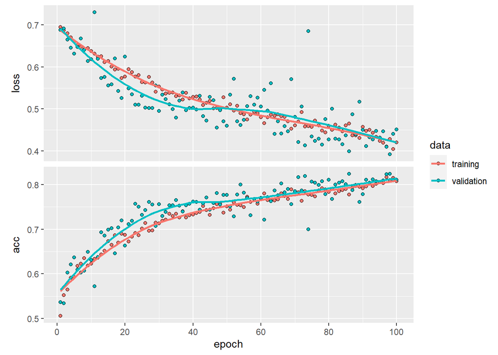

```r
plot(history3.2)
```

## Question 4

```r
base_conv <- application_vgg16(
  weights = "imagenet",
  include_top = FALSE,
  input_shape = c(150,150,3)
)
```

With this we have created the base_conv from the pretrained network that we will now apply to our model. Since I am not using a GPU, I will have to use the first method mentioned in the book to do this.

```r
datagen4 <- image_data_generator(rescale= 1/255)
batch_size <- 20

extract_features <- function(directory, sample_count) {
  features <- array(0, dim = c(sample_count,4,4,512))
  labels <- array(0, dim = c(sample_count))

  generator <- flow_images_from_directory(
    directory = directory,
    generator = datagen4,
    target_size = c(150,150),
    batch_size = batch_size,
    class_mode = "binary"
  )
  i <- 0
  while (TRUE) {
    batch <- generator_next(generator)
    inputs_batch <- batch[[1]]
    labels_batch <- batch[[2]]
    features_batch <- base_conv %>% predict(inputs_batch)

    index_range <- ((i * batch_size)+1):((i+1)*batch_size)
    features[index_range,,,] <- features_batch
    labels[index_range] <- labels_batch

    i <- i+1
    if (i * batch_size >= sample_count)
      break
  }
  list(
    features = features,
    labels = labels
  )
}

train <- extract_features(train_dir,2000)
validation <- extract_features(validation_dir,1000)
test <- extract_features(test_dir,1000)
```

After following the instructions in the book to apply a pretrained network, we now have to flatten the output.

```r
reshape_features <- function(features) {
  array_reshape(features, dim = c(nrow(features), 4*4*512))
}
train$features <- reshape_features(train$features)
validation$features <- reshape_features(validation$features)
test$features <- reshape_features(test$features)
```

Just like before, we will now use dropout to help fight overfitting.

```r
model4 <- keras_model_sequential() %>%
  layer_dense(units = 256, activation = "relu",
              input_shape = 4*4*512) %>%
  layer_dropout(rate = 0.5) %>%
  layer_dense(units = 1, activation = "sigmoid")

model4 %>% compile(
  optimizer = optimizer_rmsprop(learning_rate = 2e-5),
  loss = "binary_crossentropy",
  metrics = c("acc")
)
```

Now that we have created our new model with a pretrained network, we can now print a “history” and determine how many epochs we should use.

```r
history4 <- model4 %>% fit(
  train$features, train$labels,
  epochs = 30,
  batch_size = 20,
  validation_data = list(validation$features, validation$labels)
)
```

As seen in the plot bellow, the model very quickly overfits. Now we know that small data sets contribute to overfitting, so in the next two sections we will try to combat that.

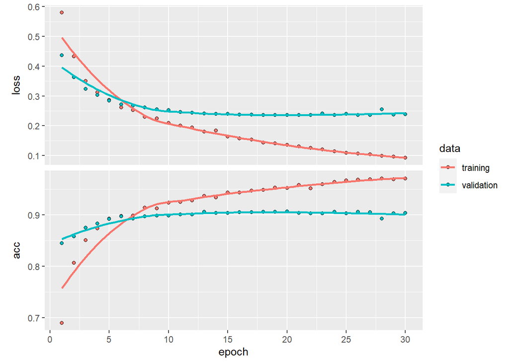

```r
plot(history4)
```

Now during the next two steps in question 4, we will be taking advantage of the directories I created for question 2 and 3 to see how increased sample size effect the model’s performance.

##Question 4.2 The code bellow recodes the extract features section and all that follows and adjusts for the new model. This section should copy Question 2 with the new pretrained network.

```r
datagen4 <- image_data_generator(rescale= 1/255)
batch_size <- 20

extract_features <- function(directory, sample_count) {
  features <- array(0, dim = c(sample_count,4,4,512))
  labels <- array(0, dim = c(sample_count))

  generator <- flow_images_from_directory(
    directory = directory,
    generator = datagen4,
    target_size = c(150,150),
    batch_size = batch_size,
    class_mode = "binary"
  )
  i <- 0
  while (TRUE) {
    batch <- generator_next(generator)
    inputs_batch <- batch[[1]]
    labels_batch <- batch[[2]]
    features_batch <- base_conv %>% predict(inputs_batch)

    index_range <- ((i * batch_size)+1):((i+1)*batch_size)
    features[index_range,,,] <- features_batch
    labels[index_range] <- labels_batch

    i <- i+1
    if (i * batch_size >= sample_count)
      break
  }
  list(
    features = features,
    labels = labels
  )
}

train <- extract_features(train_dir2,3000)
validation <- extract_features(validation_dir,1000)
test <- extract_features(test_dir,1000)
```

After following the instructions in the book to apply a pretrained network, we now have to flatten the output.

```r
reshape_features <- function(features) {
  array_reshape(features, dim = c(nrow(features), 4*4*512))
}
train$features <- reshape_features(train$features)
validation$features <- reshape_features(validation$features)
test$features <- reshape_features(test$features)
```

Just like before, we will now use dropout to help fight overfitting.

```r
model4.2 <- keras_model_sequential() %>%
  layer_dense(units = 256, activation = "relu",
              input_shape = 4*4*512) %>%
  layer_dropout(rate = 0.5) %>%
  layer_dense(units = 1, activation = "sigmoid")

model4.2 %>% compile(
  optimizer = optimizer_rmsprop(learning_rate = 2e-5),
  loss = "binary_crossentropy",
  metrics = c("acc")
)
```

Now that we have created our new model with a pretrained network, we can now print a “history” and determine how many epochs we should use.

```r
history4.2 <- model4.2 %>% fit(
  train$features, train$labels,
  epochs = 30,
  batch_size = 20,
  validation_data = list(validation$features, validation$labels)
)
```

Although we are struggling with overfitting, the model does have a very goo doutput with high accuracy (over 90%) and low loss (bellow 25%).

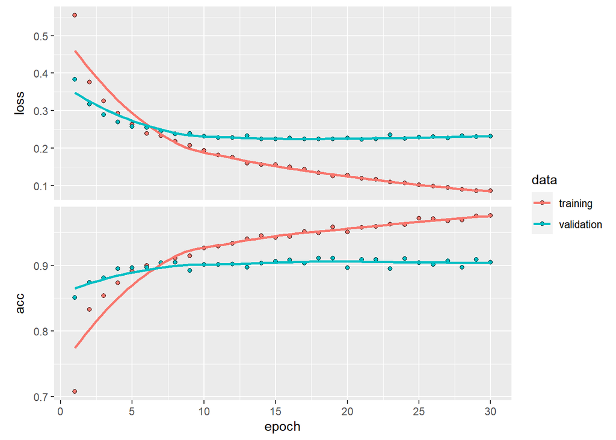

```r
plot(history4.2)
```

```r
datagen4 <- image_data_generator(rescale= 1/255)
batch_size <- 20

extract_features <- function(directory, sample_count) {
  features <- array(0, dim = c(sample_count,4,4,512))
  labels <- array(0, dim = c(sample_count))

  generator <- flow_images_from_directory(
    directory = directory,
    generator = datagen4,
    target_size = c(150,150),
    batch_size = batch_size,
    class_mode = "binary"
  )
  i <- 0
  while (TRUE) {
    batch <- generator_next(generator)
    inputs_batch <- batch[[1]]
    labels_batch <- batch[[2]]
    features_batch <- base_conv %>% predict(inputs_batch)

    index_range <- ((i * batch_size)+1):((i+1)*batch_size)
    features[index_range,,,] <- features_batch
    labels[index_range] <- labels_batch

    i <- i+1
    if (i * batch_size >= sample_count)
      break
  }
  list(
    features = features,
    labels = labels
  )
}

train4.3 <- extract_features(train_dir3,20000)
validation <- extract_features(validation_dir,1000)
test <- extract_features(test_dir,1000)
```

After following the instructions in the book to apply a pretrained network, we now have to flatten the output.

```r
reshape_features <- function(features) {
  array_reshape(features, dim = c(nrow(features), 4*4*512))
}
train$features <- reshape_features(train$features)
validation$features <- reshape_features(validation$features)
test$features <- reshape_features(test$features)
```

Just like before, we will now use dropout to help fight overfitting.

```r
model4.3 <- keras_model_sequential() %>%
  layer_dense(units = 256, activation = "relu",
              input_shape = 4*4*512) %>%
  layer_dropout(rate = 0.5) %>%
  layer_dense(units = 1, activation = "sigmoid")

model4.3 %>% compile(
  optimizer = optimizer_rmsprop(learning_rate = 2e-5),
  loss = "binary_crossentropy",
  metrics = c("acc")
)
```

Now that we have created our new model with a pretrained network, we can now print a “history” and determine how many epochs we should use.

```r
history4.3 <- model4.3 %>% fit(
  train$features, train$labels,
  epochs = 30,
  batch_size = 20,
  validation_data = list(validation$features, validation$labels)
)
```

With that said, this model still performs well despite the overfitting. This just goes to show how important the augmentation was that we used in questions 1-3.

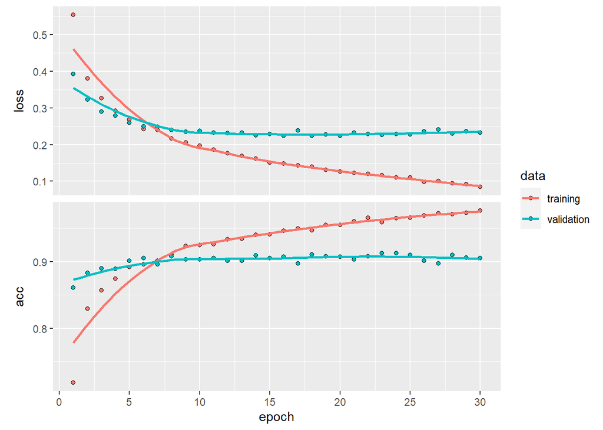

```r
plot(history4.3)
```

In the end, while using pretrained networks is super useful, the biggest downside is that I am unable to use augmentation (like I was using in the previous questions) which, evidently, is very important in fighting overfitting. Even though, we are getting good accuracy results, the lack of augmentation makes this method less useful, in future efforts to optimize this model, I should set up a GPU that can handle the second way to use pretrained networks so that augmentation can be implemented.